# Bayesian Network Building

Angela Yoder

2022-07-29

**The goals of this program are:**

1. Triplet Summary
2. Create and Visualize Bayesian Network with Triplet

```r
# all triplet summary code from Create_Triplet.Rmd

setwd("C:/Users/yodeange/OneDrive - The University of Colorado Denver/Saba Lab/Data")

summ.brain = read.csv("Summary_Table_topSsec_brain.csv")
summ.liver = read.csv("Summary_Table_topSsec_liver.csv")
te.sec.b_table = read.csv("eQTL_BrainTESec_added_table.csv")
te.sec.l_table = read.csv("eQTL_LiverTESec_added_table.csv")
geno = read.csv("ALTGenoMAFnomiss_rQTL.csv")
protein_liver = read.csv("Liver_WGCNA.csv")
protein_brain = read.csv("Brain_WGCNA.csv")
bicor_brain = read.csv("Bicor_brain.csv")
bicor_liver = read.csv("Bicor_liver.csv")
pheno = read.csv("Pheno_rQTL.csv")

fix.read.csv = function(x)
{
  names = x[,1]
  gee = x[,2:dim(x)[2]]
  rownames(gee) = names
  return(gee)
}
`%!in%` = Negate(`%in%`)

summ.brain = fix.read.csv(summ.brain)
summ.liver = fix.read.csv(summ.liver)
eqtl.brain = fix.read.csv(te.sec.b_table)
eqtl.liver = fix.read.csv(te.sec.l_table)
protein_brain = fix.read.csv(protein_brain)
protein_liver = fix.read.csv(protein_liver)
bicor_brain = fix.read.csv(bicor_brain)
bicor_liver = fix.read.csv(bicor_liver)

protein_brain = protein_brain[pheno$ID,]
protein_liver = protein_liver[pheno$ID,]
```

```r
################ Do we need this? ##################

# top target genes

all_corr = bicor_brain[rownames(bicor_brain) == "ENSRNOG00000005781",]
top_corr = all_corr[all_corr < 0.05]

# correlations
snp.brain = geno$J588980[-c(1, 2)]
transcript.brain = protein_brain$ENSRNOG00000005781
pheno.brain = pheno$meanauc2gkg

corr.brain.snptrans = cor.test(snp.brain, transcript.brain)
corr.brain.snppheno = cor.test(snp.brain, pheno.brain)
corr.brain.transpheno = cor.test(transcript.brain, pheno.brain)

# table

summary = data.frame(Ensembl = "ENSRNOG00000005781", Gene.Symbol = "Wnt16", SNP = "J588980", eQTL.pval = "0.033", eQTL.FDR = "0.3441", cis.trans = "trans", heritability = "0.4650", Ssec = "09592", Num.Target.Genes = length(top_corr), pQTL.LOD = "2.25 (4.31, 2.57)", Corr.SNP.Transcript = paste(corr.brain.snptrans$estimate, corr.brain.snptrans$p.value), Corr.SNP.Pheno = paste(corr.brain.snppheno$estimate, corr.brain.snppheno$p.value), Corr.Transcript.Pheno = paste(corr.brain.transpheno$estimate, corr.brain.transpheno$p.value))

knitr::kable(summary)
```

[output not shown]

```r
  # snp x transcript

plot(x = factor(snp.brain, levels = c(0, 2)), y = transcript.brain, xlab = "Genotype", ylab = "Phenotype: Transcript Expression", main = "Plot of Genotype x Gene Expression for \n SNP J588980 and Gene Wnt16", sub = paste("Correlation = ", round(corr.brain.snptrans$estimate, 3), ", P-value = ", corr.brain.snptrans$p.value))

  # snp x phenotype

plot(x = factor(snp.brain, levels = c(0, 2)), y = pheno.brain, xlab = "Genotype", ylab = "Phenotype: Acetate AUC", main = "Plot of Genotype x Phenotype for \n SNP J588980 and Acetate AUC", sub = paste("Correlation = ", round(corr.brain.snppheno$estimate, 3), ", P-value = ", corr.brain.snppheno$p.value))

  # transcript x phenotype

plot(x = transcript.brain, y = pheno.brain, xlab = "Transcript Expression", ylab = "Acetate AUC", main = "Plot of Gene Expression x Phenotype for \n Gene Wnt16 and Acetate AUC", sub = paste("Correlation = ", round(corr.brain.transpheno$estimate, 3), ", P-value = ", corr.brain.transpheno$p.value))
```

[output not shown]

## SNP-Transcript-Phenotype Triplet Bayesian Network

I’m still working out the kinks with this one, but I have managed to build a Bayesian network with a hill-climbing algorithm, displayed in plot below. All edges out of the phenotype node and all edges into the SNP node were blacklisted. I have also calculated expected log-likelihood loss for a null network with no edges and the hill climbing algorithm network using k-fold cross-validation, shown below. I am still planning on testing individual edges to get p-values.

```r
#https://www.bnlearn.com/examples/fit/
#https://www.bnlearn.com/examples/ci.test/
#https://www.bnlearn.com/examples/

library(bnlearn)
######################## TRIPLETS ####################################

# Wnt16: eQTL with correlation to phenotype (SNP/Transcript/Pheno)
triplet = data.frame(SNP = geno$J588980[-c(1:2)], Transcript = protein_brain$ENSRNOG00000005781, Phenotype = pheno$meanauc2gkg)
rownames(triplet) = pheno$ID
triplet$SNP = factor(triplet$SNP)

# Cntn4: eQTL with correlation to phenotype (SNP/Transcript/Pheno)
triplet.1 = data.frame(SNP = geno$WKYc21g03_r1_229[-c(1, 2)], Transcript = protein_brain$ENSRNOG00000005652, Phenotype = pheno$ClearanceEtOH)
rownames(triplet.1) = pheno$ID
triplet.1$SNP = factor(triplet.1$SNP)
triplet.1clean = triplet.1[!is.na(triplet.1$SNP),] # missing SNP at 10

## Ibsp: Highest sig eQTL (SNP/Transcript/Target)

target.genes = bicor_brain[rownames(bicor_brain) == "ENSRNOG00000002158",]
thisone = which(target.genes == min(target.genes))
target.name = names(target.genes)[69]

triplet.2 = data.frame(SNP = geno$J506605[-c(1:2)], TES = protein_brain$ENSRNOG00000002158, Target = protein_liver[, colnames(protein_liver) == target.name])
rownames(triplet.2) = geno[-c(1:2),1]
triplet.2$SNP = factor(triplet.2$SNP)

## Cntn4: Highest Ssec with sig eQTL (SNP/Transcript/Target)

target.genes = bicor_brain[rownames(bicor_brain) == "ENSRNOG00000005652",]
thisone = which(target.genes == min(target.genes))
target.name = names(target.genes)[thisone]

triplet.3 = data.frame(SNP = geno$WKYc21g03_r1_229[-c(1:2)], TES = protein_brain$ENSRNOG00000005652, Target = protein_liver[, colnames(protein_liver) == target.name])
rownames(triplet.3) = geno[-c(1:2),1]
triplet.3$SNP = factor(triplet.3$SNP)
triplet.3clean = triplet.3[!is.na(triplet.3$SNP),] # missing SNP at 10
```

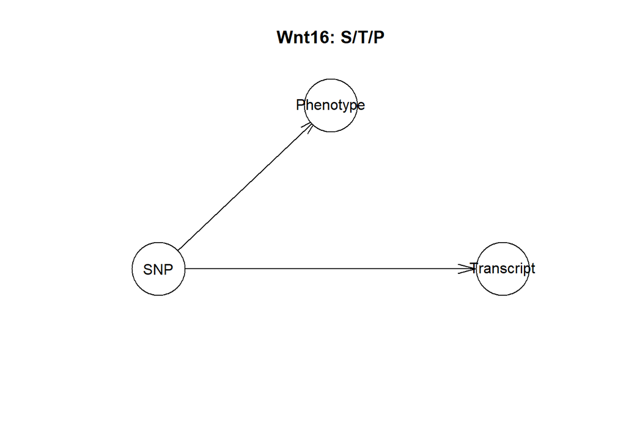

```r
# dag we're hoping for
arc.set = data.frame(from = c("SNP", "Transcript", "SNP"), to = c("Transcript", "Phenotype", "Phenotype"))
dag = empty.graph(nodes = c("SNP", "Transcript", "Phenotype"))
arcs(dag) = arc.set
# null dag
null = empty.graph(nodes = c("SNP", "Transcript", "Phenotype"))
# blacklist
bl = data.frame(from = c("Phenotype", "Phenotype", "Transcript"), to = c("Transcript", "SNP", "SNP"))
bl.1 = data.frame(from = c("Target", "Target", "TES"), to = c("TES", "SNP", "SNP"))

bn = hc(triplet, blacklist = bl)

bn.1 = hc(triplet.1clean, blacklist = bl)

bn.2 = hc(triplet.2, blacklist = bl.1)

bn.3 = hc(triplet.3clean, blacklist = bl.1)

plot(bn, main = "Wnt16: S/T/P")
```

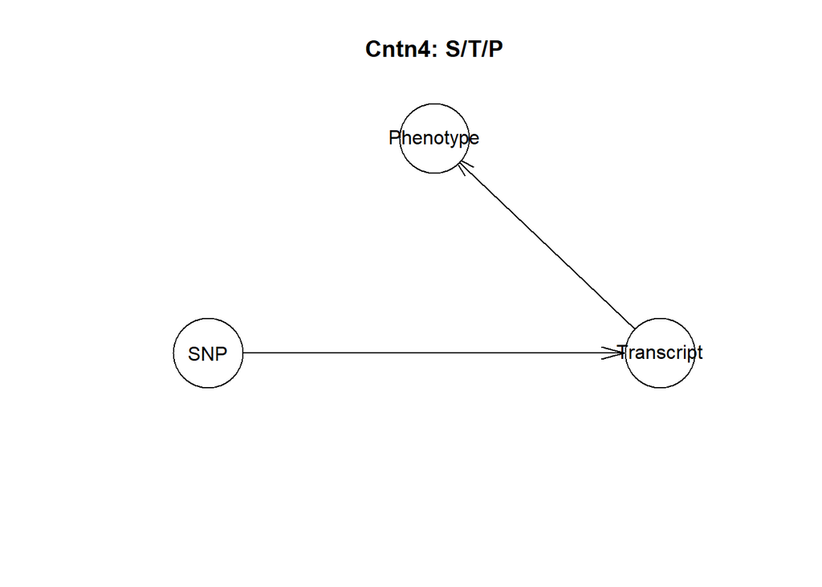

```r
plot(bn.1, main = "Cntn4: S/T/P")
```

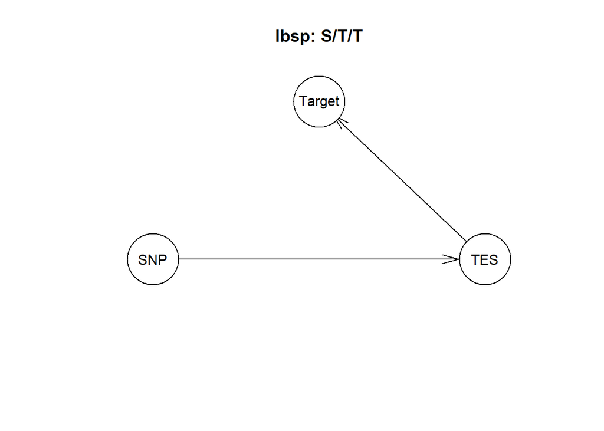

```r
plot(bn.2, main = "Ibsp: S/T/T")
```

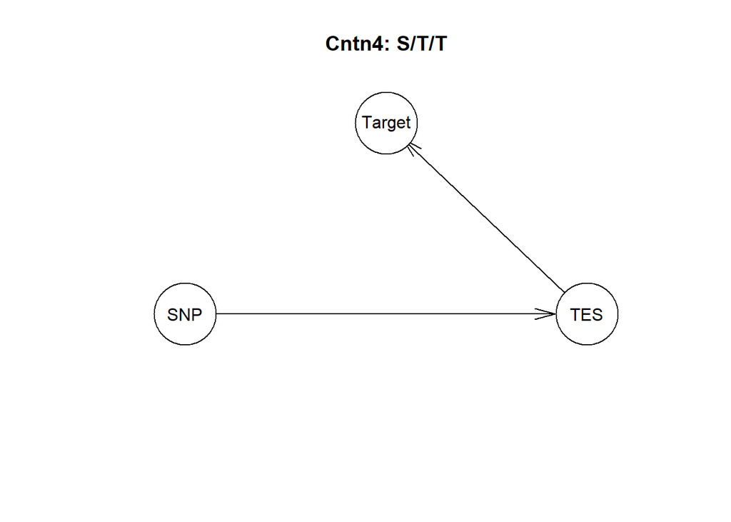

```r
plot(bn.3, main = "Cntn4: S/T/T")
```

We can see below that the null network had a higher expected log-likelihood loss than the learned network. Both used ten folds to calculate loss. I can increase the number of folds if necessary.

```r
############ FIX THIS #################
# goodness of fit- im guessing since we can calculate BIC, we can only compare networks with the same nodes. So i think what we're going to do is calculate BIC for fitted network and compare to other networks that are artificially made
print("Learned Network")
```

```
## [1] "Learned Network"
```

```r
bn.cv(data = triplet, bn = bn, method = "k-fold")
```

```
##
##   k-fold cross-validation for Bayesian networks
##
##   target network structure:
##    [SNP][Transcript|SNP][Phenotype|SNP]
##   number of folds:                       10
##   loss function:                         Log-Likelihood Loss (cond. Gauss.)
##   expected loss:                         5.744655
```

```r
print("Transcript Influence Network")
```

```
## [1] "Transcript Influence Network"
```

```r
bn.cv(data = triplet, bn = dag, method = "k-fold")
```

```
##
##   k-fold cross-validation for Bayesian networks
##
##   target network structure:
##    [SNP][Transcript|SNP][Phenotype|SNP:Transcript]
##   number of folds:                       10
##   loss function:                         Log-Likelihood Loss (cond. Gauss.)
##   expected loss:                         5.837156
```

```r
print("Null Network")
```

```
## [1] "Null Network"
```

```r
bn.cv(data = triplet, bn = null, method = "k-fold")
```

```
##
##   k-fold cross-validation for Bayesian networks
##
##   target network structure:
##    [SNP][Transcript][Phenotype]
##   number of folds:                       10
##   loss function:                         Log-Likelihood Loss (cond. Gauss.)
##   expected loss:                         6.117632
```

```r
## test individual edges
```

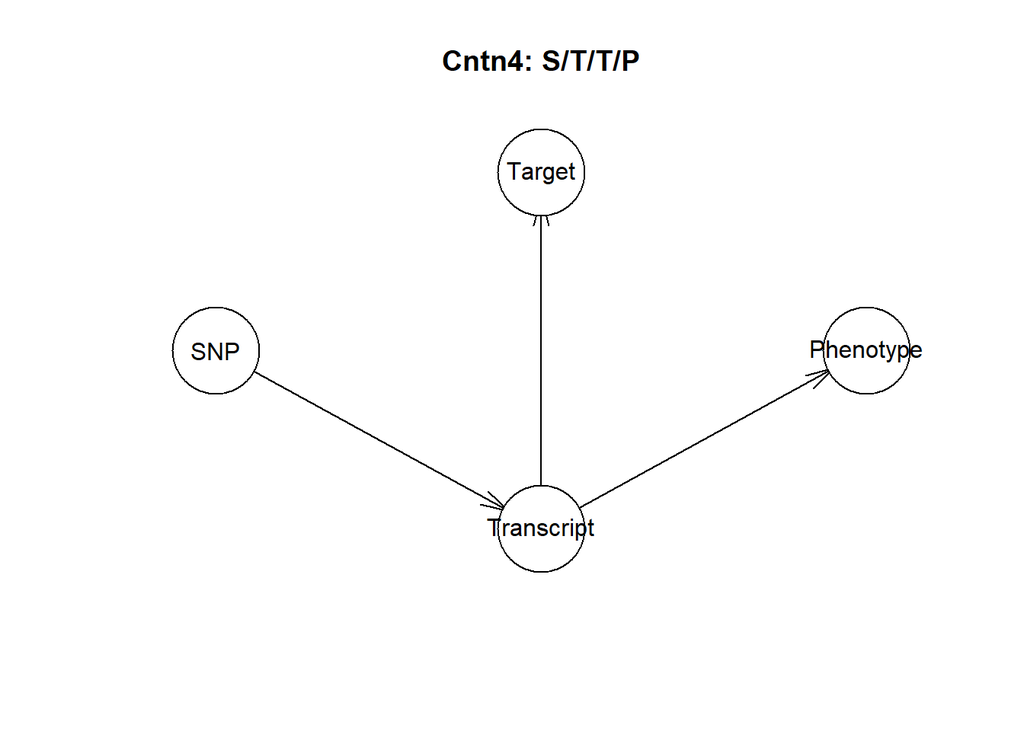

```r
# Quadruple

quad = data.frame(triplet.1clean, triplet.3clean$Target)
colnames(quad)[4] = "Target"
bl.2 = data.frame(from = c("Target", "Target", "Transcript", "Phenotype", "Phenotype", "Phenotype"), to = c("Transcript", "SNP", "SNP", "SNP", "Transcript", "Target"))

bn.q = hc(quad, blacklist = bl.2)

plot(bn.q, main = "Cntn4: S/T/T/P")
```

## AIM 3B: Testing Bayesian Network

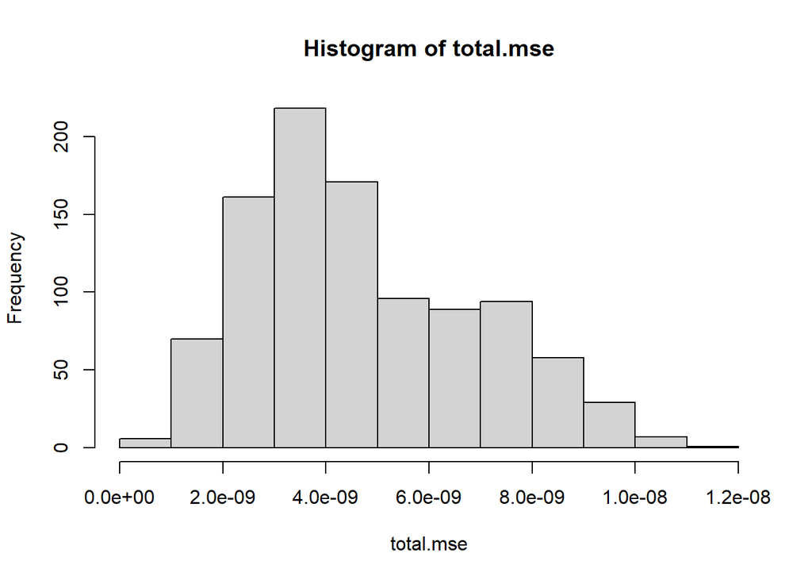

```r
# https://www.bnlearn.com/documentation/man/impute.html

mse = function(x, y)
{
  out = (1/length(x)) * sum((x - y)^2)
  return(out)
}

set.seed(444)
total.mse = numeric(1000)
for (i in 1:1000)
{
  training.set = sort(sample(1:29, 22))
  test.set = c(1:29)[1:29 %!in% training.set]
  train.data = triplet.1clean[training.set,]
  test.data = triplet.1clean[test.set,]

  training = bn.fit(bn.1, train.data)
  predicted = predict(training, node = "Phenotype", data = test.data)

  meanse = mse(predicted, test.data$Phenotype)

  total.mse[i] = meanse
  #print(mean(accuracy(predicted, test.data$Phenotype)))
}

hist(total.mse)
```

## AIM 3C: Predict Phenotypes

```r
setwd("C:/Users/yodeange/OneDrive - The University of Colorado Denver/Saba Lab/Data")
full.geno = read.csv("full_hrdp_geno.csv")
full.geno = t(full.geno)
full.rnaseq.brain = read.delim("PhenoGen.HRDP.v5.totalRNA.Brain.gene.ensembl96.txt", sep = "\t")
full.rnaseq.liver = read.delim("PhenoGen.HRDP.v5.totalRNA.Liver.gene.ensembl96.txt", sep = "\t")
```

```r
############# Cleaning RNAseq ###########

inbred.rnaseq.brain = full.rnaseq.brain[,-grep("HXB|BXH", colnames(full.rnaseq.brain))]
inbred.rnaseq.liver = full.rnaseq.liver[,-grep("HXB|BXH", colnames(full.rnaseq.liver))]


strains.brain = sub("_.*", "", colnames(inbred.rnaseq.brain))
strains.liver = sub("_.*", "", colnames(inbred.rnaseq.liver))
unique.strains.brain = unique(strains.brain)
unique.strains.liver = unique(strains.liver)

strainmeans.brain = matrix(NA, nrow = nrow(inbred.rnaseq.brain), ncol = length(unique.strains.brain))
strainmeans.brain = as.data.frame(strainmeans.brain)
for (i in 1:length(unique.strains.brain))
{
  means = grep(unique.strains.brain[i], colnames(inbred.rnaseq.brain))
  df = inbred.rnaseq.brain[,means]
  out = apply(df, 1, mean)
  strainmeans.brain[,i] = out
}

rownames(strainmeans.brain) = rownames(inbred.rnaseq.brain)
colnames(strainmeans.brain) = unique.strains.brain

strainmeans.liver = matrix(NA, nrow = nrow(inbred.rnaseq.liver), ncol = length(unique.strains.liver))
strainmeans.liver = as.data.frame(strainmeans.liver)
for (i in 1:length(unique.strains.liver))
{
  means = grep(unique.strains.liver[i], colnames(inbred.rnaseq.liver))
  df = inbred.rnaseq.liver[,means]
  out = apply(df, 1, mean)
  strainmeans.liver[,i] = out
}

rownames(strainmeans.liver) = rownames(inbred.rnaseq.liver)
colnames(strainmeans.liver) = unique.strains.liver

strainmeans.liver = strainmeans.liver[, unique.strains.brain]


strainmeans.brain = t(strainmeans.brain)
strainmeans.liver = t(strainmeans.liver)

## GENO

edit.geno = full.geno[-c(1:3), ]
colnames(edit.geno) = full.geno[1,]
inbred.geno = edit.geno[rownames(edit.geno) %in% rownames(strainmeans.brain),]

red.strainmeans.brain = strainmeans.brain[rownames(strainmeans.brain) %in% rownames(inbred.geno),]
red.strainmeans.liver = strainmeans.liver[rownames(strainmeans.liver) %in% rownames(inbred.geno),]

inbred.geno = as.data.frame(inbred.geno)

red.strainmeans.brain = as.data.frame(red.strainmeans.brain)

red.strainmeans.brain = red.strainmeans.brain[rownames(inbred.geno),]
```

```r
# Cntn4: eQTL with correlation to phenotype (SNP/Transcript/Pheno)
triplet.1 = data.frame(SNP = geno$WKYc21g03_r1_229[-c(1, 2)], Transcript = protein_brain$ENSRNOG00000005652, Phenotype = pheno$ClearanceEtOH)
rownames(triplet.1) = pheno$ID
triplet.1$SNP = factor(triplet.1$SNP)
triplet.1clean = triplet.1[!is.na(triplet.1$SNP),] # missing SNP at 10

test.data = data.frame(SNP = inbred.geno$WKYc21g03_r1_229, Transcript = red.strainmeans.brain$ENSRNOG00000005652)
rownames(test.data) = rownames(inbred.geno)
test.data$SNP = factor(test.data$SNP)

training = bn.fit(bn.1, triplet.1clean)
predicted = predict(training, node = "Phenotype", data = test.data)
```